# Genetic correlations & variance components from bivariate Gibbs sampling models

# Notes & questions

- Plotted distributions of heritabilities/genetic correlations represent the distribution of 9,500 sample-by-sample estimates
- Highest posterior density intervals calculated with `{coda}` package based on distribution of the 9,500 sample-by-sample heritability or genetic correlation estimates

*Overview of conclusions/questions:*

- High Plains “control” $r_g$ estimates aren’t much higher than most of the other comparison region estimates
- How much of our results can we safely are a result of GxE vs. pedigree relatedness between samples?
  - Does it matter? Are the conclusions the same?
- I’m still convinced that GxE matters in some parts of the U.S., I’m just not sure if the magnitude of the effect is as large as we previously thought/it’s not as straight forward as we thought

# Setup

```r
gibbs_samples <-
  purrr::map2_dfr(.x = rep(c(1:10),
                           times = 7),
                  .y = rep(c("1", "2", "3alt", "5", "7", "8", "9"),
                           times = 10),
                  ~ read_gibbs_samples(iteration = .x,
                                 region = .y)) %>%
  select(iter, dataset, everything(), -X1, -X3) %>%
  purrr::set_names("iter", "dataset", "round", c(1:14)) %>%
  tidyr::pivot_longer(cols = c(`1`:`14`),
                      names_to = "param") %>%
  mutate(param = case_when(param == "1" ~ "dir1dir1",
                           param == "2" ~ "dir1dir2",
                           param == "3" ~ "dir1mat1",
                           param == "4" ~ "dir1mat2",
                           param == "5" ~ "dir2dir2",
                           param == "6" ~ "dir2mat1",
                           param == "7" ~ "dir2mat2",
                           param == "8" ~ "mat1mat1",
                           param == "9" ~ "mat1mat2",
                           param == "10" ~ "mat2mat2",
                           param == "11" ~ "mpe1mpe1",
                           param == "12" ~ "mpe2mpe2",
                           param == "13" ~ "res1res1",
                           param == "14" ~ "res2res2"),
         iter = as.character(iter))
```

```r
n_samples <-
  gibbs_samples %>%
  group_by(iter, dataset, param) %>%
  tally(name = "n_samples") %>%
  ungroup() %>%
  mutate(iter = as.numeric(iter)) %>%
  distinct(iter, dataset, n_samples)
```

```r
gibbs_varcomp <-
  purrr::map2_dfr(.x = rep(c(1:10),
                           times = 7),
                  .y = rep(c("1", "2", "3alt", "5", "7", "8", "9"),
                           times = 10),
                  ~ read_gibbs_varcov(iteration = .x,
                                      dataset = .y))
```

```r
gibbs_corr <-
  purrr::map2_dfr(.x = rep(c(1:10),
                           times = 7),
                  .y = rep(c("1", "2", "3alt", "5", "7", "8", "9"),
                           times = 10),
                  ~ read_gibbs_corr(iteration = .x,
                                    dataset = .y))
```

```r
gibbs_h2 <-
  purrr::map2_dfr(.x = rep(c(1:10),
                           times = 7),
                  .y = rep(c("1", "2", "3alt", "5", "7", "8", "9"),
                           times = 10),
                  ~ read_gibbs_h2(iteration = .x,
                                  dataset = .y))
```

```r
h2_sample <-
  gibbs_samples %>%
  tidyr::pivot_wider(id_cols = c("iter", "dataset", "round"),
                     names_from = param,
                     values_from = value) %>%
  # This is janky but it's a lot faster
  mutate(# maternal h2
         mat1h2 = (mat1mat1/(dir1dir1+dir1mat1+mat1mat1+mpe1mpe1+res1res1)),
         mat2h2 = (mat2mat2/(dir2dir2+dir2mat2+mat2mat2+mpe2mpe2+res2res2)),
         # direct h2
         dir1h2 = (dir1dir1/(dir1dir1+dir1mat1+mat1mat1+mpe1mpe1+res1res1)),
         dir2h2 = (dir2dir2/(dir2dir2+dir2mat2+mat2mat2+mpe2mpe2+res2res2)),
         mpe1c2 = (mpe1mpe1/(dir1dir1+dir1mat1+mat1mat1+mpe1mpe1+res1res1)),
         # mpe c2
         mpe2c2 = (mpe2mpe2/(dir2dir2+dir2mat2+mat2mat2+mpe2mpe2+res2res2)),
         iter = as.numeric(iter)) %>%
  select(iter, dataset, round, mat1h2, mat2h2, dir1h2, dir2h2, mpe1c2, mpe2c2)
```

```r
rg_sample <-
  gibbs_samples %>%
  tidyr::pivot_wider(id_cols = c("iter", "dataset", "round"),
                     names_from = param,
                     values_from = value) %>%
  # This is janky but it's a lot faster
  mutate(# HP dir-other dir
         rgdir1dir2 = (dir1dir2/(sqrt(dir1dir1*dir2dir2))),
         # HP mat-other mat
         rgmat1mat2 = (mat1mat2/(sqrt(mat1mat1*mat2mat2))),
         # HP dir-other mat
         rgdir1mat2 = (dir1mat2/(sqrt(dir1dir1*mat2mat2))),
         # dir-mat within region
         rgdir2mat2 = (dir2mat2/(sqrt(dir2dir2*mat2mat2))),
         rgdir1mat1 = (dir1mat1/(sqrt(dir1dir1*mat1mat1))),
         iter = as.numeric(iter)) %>%
  select(iter, dataset, round, starts_with("rg"))
```

```r
plot_dist_grid <-
  function(df, var) {
    var <- rlang::enquo(var)

    df %>%
      mutate(iter = as.numeric(iter)) %>%
      arrange(iter) %>%
      mutate(iter = glue("Iteration {iter}"),
             iter = forcats::fct_inorder(as.factor(iter)),
             num = as.numeric(str_extract(dataset, "(?<=3v)[[:digit:]]"))) %>%
      left_join(region_key) %>%
      ggplot(aes(x = !!var,
                 fill = color1)) +
      geom_density() +
      theme_classic() +
      scale_fill_identity() +
      labs(x = "Estimate",
           y = "Kernel density") +
      facet_grid(rows = vars(iter),
                 cols = vars(desc))
  }
```

```r
hpd <-
  h2_sample %>%
  left_join(rg_sample) %>%
  tidyr::pivot_longer(cols = -one_of("iter", "dataset", "round")) %>%
  group_by(iter, dataset, name) %>%
  tidyr::nest() %>%
  ungroup() %>%
  mutate(value = purrr::map(.x = data,
                            ~ .x %>%
                              pull(value)),
         hpd_int = purrr::map(.x = value,
                              ~ .x %>%
                                coda::as.mcmc() %>%
                                coda::HPDinterval()),
         hpd_lower = purrr::map_dbl(.x = hpd_int,
                                    ~ .x %>%
                                      pluck(1)),
         hpd_upper = purrr::map_dbl(.x = hpd_int,
                                    ~ .x %>%
                                      pluck(2))) %>%
  select(param = name, everything(), -data, -value, -hpd_int)
```

```r
pivot_hpd <-
  function(which) {
    hpd %>%
      filter(param == which) %>%
      mutate(diff = abs(hpd_upper-hpd_lower),
             int = as.character(glue("{round(hpd_lower, digits = 3)}, {round(hpd_upper, digits = 3)} ({round(diff, digits = 3)})")),
             iter = as.character(glue("Iteration {iter}"))) %>%
      select(iter, Dataset = dataset, int) %>%
      tidyr::pivot_wider(names_from = iter,
                         values_from = int)
  }
```

# Heritabilities

## All heritabilities, all comparisons, all iterations

```r
gibbs_h2 %>%
  left_join(n_samples) %>%
  filter(n_samples >= complete_samples) %>%
  mutate(key = if_else(key == "High Plains", "High Plains (anchor)", key)) %>%
  select(Comparison = key, Iteration = iter, everything(), -n_samples, -dataset) %>%
  arrange(Comparison, Iteration) %>%
  DT::datatable()
```

|  | Comparison | Iteration | Total variance | Direct h2 | Maternal h2 | MPE c2 |
| --- | --- | --- | --- | --- | --- | --- |
| 1 | Arid Prairie | 1 | 599.167 | 0.32615280881624 | 0.119497569125135 | 0.134860564750729 |
| 2 | Arid Prairie | 2 | 578.942 | 0.289407229048851 | 0.126693174791257 | 0.151649042563849 |
| 3 | Arid Prairie | 3 | 601.676 | 0.296388754080269 | 0.10824430424348 | 0.136146364488529 |
| 4 | Arid Prairie | 4 | 615.94 | 0.27876091827126 | 0.123294476734747 | 0.144691041335195 |
| 5 | Arid Prairie | 5 | 600.466 | 0.317886441530411 | 0.111798170087898 | 0.122045211552361 |
| 6 | Arid Prairie | 6 | 647.931 | 0.257620024354445 | 0.132173024596755 | 0.109349606671081 |
| 7 | Arid Prairie | 7 | 625.466 | 0.310200714347383 | 0.13501773077993 | 0.120466979819846 |
| 8 | Arid Prairie | 8 | 603.021 | 0.293107536885117 | 0.141394744129972 | 0.13094071350749 |
| 9 | Arid Prairie | 9 | 598.144 | 0.285566686282902 | 0.10736545046009 | 0.132715533383266 |
| 10 | Arid Prairie | 10 | 610.273 | 0.278137817009764 | 0.116184068441501 | 0.121434177818779 |

[output cut: 130 more lines]

## Weaning weight direct $h^2_D$

### Summarized by comparison across iterations

```r
gibbs_h2 %>%
  mutate(key = if_else(key == "High Plains", "High Plains (anchor)", key)) %>%
  group_by(key) %>%
  summarise(`Min h2D` = min(`Direct h2`),
            `Mean h2D` = mean(`Direct h2`),
            `Max h2D` = max(`Direct h2`),
            n = n())
```

| key | Min h2D | Mean h2D | Max h2D | n |
| --- | --- | --- | --- | --- |
| Arid Prairie | 0.2576200 | 0.2933229 | 0.3261528 | 10 |
| Desert | 0.2715359 | 0.3260333 | 0.3848401 | 10 |
| Fescue Belt | 0.2459651 | 0.2915623 | 0.3408024 | 10 |
| Forested Mountains | 0.2230792 | 0.2526656 | 0.2898781 | 10 |
| High Plains (anchor) | 0.2234253 | 0.3016198 | 0.4021501 | 70 |
| High Plains (control) | 0.1951414 | 0.2981324 | 0.3514749 | 10 |
| Southeast | 0.2234285 | 0.2842418 | 0.3157857 | 10 |
| Upper Midwest & Northeast | 0.2554400 | 0.2978122 | 0.3460206 | 10 |

### Distribution

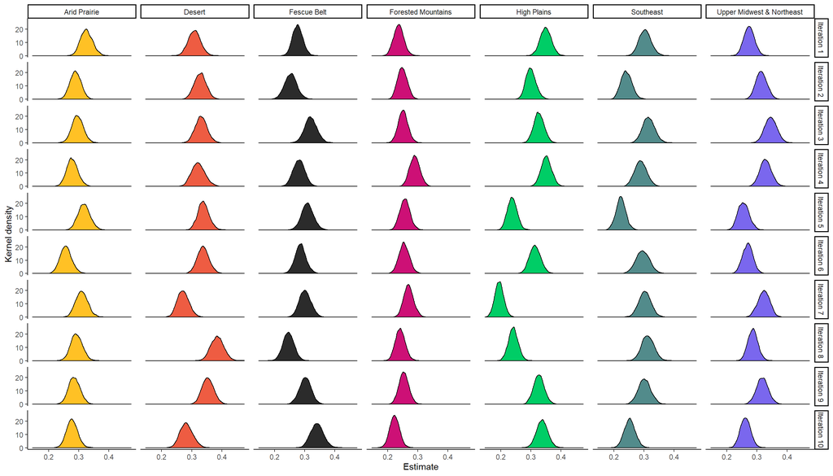

```r
plot_dist_grid(df = h2_sample %>%
                 left_join(n_samples) %>%
                 filter(n_samples >= complete_samples),
               var = dir2h2)
```

### HPD interval

```r
pivot_hpd("dir2h2")
```

| Dataset | Iteration 1 | Iteration 2 | Iteration 3 | Iteration 4 | Iteration 5 | Iteration 6 | Iteration 7 | Iteration 8 | Iteration 9 | Iteration 10 |
| --- | --- | --- | --- | --- | --- | --- | --- | --- | --- | --- |
| 3v1 | 0.267, 0.349 (0.082) | 0.289, 0.367 (0.078) | 0.293, 0.372 (0.078) | 0.28, 0.367 (0.087) | 0.304, 0.378 (0.074) | 0.3, 0.378 (0.078) | 0.235, 0.311 (0.076) | 0.343, 0.426 (0.083) | 0.317, 0.392 (0.076) | 0.242, 0.325 (0.083) |
| 3v2 | 0.265, 0.344 (0.079) | 0.206, 0.277 (0.071) | 0.274, 0.354 (0.08) | 0.251, 0.33 (0.079) | 0.191, 0.256 (0.065) | 0.253, 0.343 (0.089) | 0.262, 0.342 (0.08) | 0.275, 0.356 (0.08) | 0.263, 0.344 (0.082) | 0.218, 0.289 (0.072) |
| 3v3alt | 0.312, 0.386 (0.074) | 0.267, 0.335 (0.067) | 0.294, 0.361 (0.067) | 0.317, 0.386 (0.07) | 0.207, 0.269 (0.062) | 0.276, 0.35 (0.073) | 0.166, 0.224 (0.058) | 0.208, 0.272 (0.063) | 0.291, 0.361 (0.07) | 0.301, 0.376 (0.075) |
| 3v5 | 0.288, 0.366 (0.079) | 0.254, 0.326 (0.072) | 0.259, 0.336 (0.077) | 0.241, 0.316 (0.075) | 0.278, 0.357 (0.079) | 0.217, 0.294 (0.077) | 0.27, 0.348 (0.078) | 0.256, 0.332 (0.076) | 0.25, 0.326 (0.075) | 0.242, 0.315 (0.073) |
| 3v7 | 0.203, 0.269 (0.067) | 0.218, 0.28 (0.062) | 0.218, 0.282 (0.065) | 0.257, 0.323 (0.067) | 0.225, 0.291 (0.066) | 0.221, 0.289 (0.069) | 0.24, 0.305 (0.065) | 0.211, 0.274 (0.063) | 0.221, 0.285 (0.064) | 0.19, 0.254 (0.064) |
| 3v8 | 0.244, 0.311 (0.067) | 0.213, 0.295 (0.082) | 0.28, 0.361 (0.082) | 0.243, 0.318 (0.075) | 0.268, 0.347 (0.079) | 0.249, 0.323 (0.074) | 0.265, 0.34 (0.075) | 0.211, 0.283 (0.072) | 0.26, 0.338 (0.077) | 0.299, 0.382 (0.084) |
| 3v9 | 0.24, 0.309 (0.069) | 0.279, 0.352 (0.072) | 0.307, 0.385 (0.079) | 0.29, 0.367 (0.077) | 0.222, 0.293 (0.071) | 0.236, 0.303 (0.068) | 0.283, 0.358 (0.075) | 0.253, 0.319 (0.065) | 0.28, 0.358 (0.078) | 0.228, 0.295 (0.067) |

## Weaning weight maternal $h^2_M$

### Summarized by comparison across iterations

- Maybe interesting that Southeast tends to have higher $h^2_M$. Same result using previous strategy

```r
gibbs_h2 %>%
  mutate(key = if_else(key == "High Plains", "High Plains (anchor)", key)) %>%
  group_by(key) %>%
  summarise(`Min h2M` = min(`Maternal h2`),
            `Mean h2M` = mean(`Maternal h2`),
            `Max h2M` = max(`Maternal h2`),
            n = n())
```

| key | Min h2M | Mean h2M | Max h2M | n |
| --- | --- | --- | --- | --- |
| Arid Prairie | 0.10736545 | 0.1221663 | 0.1413947 | 10 |
| Desert | 0.08700641 | 0.1117240 | 0.1336888 | 10 |
| Fescue Belt | 0.08920790 | 0.1294857 | 0.1572954 | 10 |
| Forested Mountains | 0.08450834 | 0.1092877 | 0.1324736 | 10 |
| High Plains (anchor) | 0.08136637 | 0.1172921 | 0.1562077 | 70 |
| High Plains (control) | 0.09298735 | 0.1185224 | 0.1372886 | 10 |
| Southeast | 0.12438150 | 0.1479921 | 0.1655105 | 10 |
| Upper Midwest & Northeast | 0.08858269 | 0.1210370 | 0.1494379 | 10 |

### Distribution

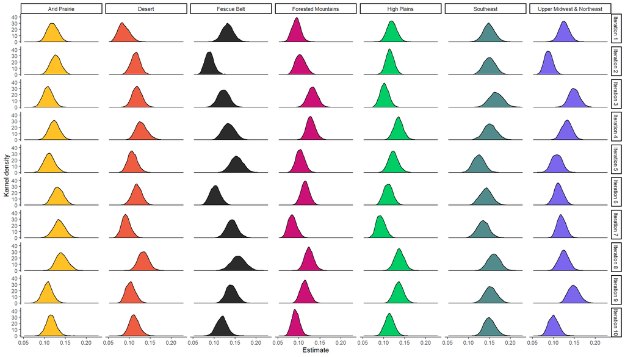

```r
plot_dist_grid(df = h2_sample %>%
                 left_join(n_samples) %>%
                 filter(n_samples >= complete_samples),
               var = mat2h2)
```

### HPD interval

```r
pivot_hpd("mat2h2")
```

| Dataset | Iteration 1 | Iteration 2 | Iteration 3 | Iteration 4 | Iteration 5 | Iteration 6 | Iteration 7 | Iteration 8 | Iteration 9 | Iteration 10 |
| --- | --- | --- | --- | --- | --- | --- | --- | --- | --- | --- |
| 3v1 | 0.062, 0.112 (0.05) | 0.093, 0.136 (0.043) | 0.096, 0.142 (0.046) | 0.103, 0.157 (0.055) | 0.086, 0.131 (0.045) | 0.094, 0.141 (0.048) | 0.071, 0.114 (0.043) | 0.109, 0.158 (0.05) | 0.082, 0.126 (0.044) | 0.089, 0.137 (0.047) |
| 3v2 | 0.121, 0.176 (0.055) | 0.121, 0.176 (0.055) | 0.133, 0.196 (0.064) | 0.121, 0.182 (0.062) | 0.096, 0.149 (0.053) | 0.113, 0.17 (0.057) | 0.107, 0.163 (0.056) | 0.133, 0.188 (0.055) | 0.125, 0.182 (0.058) | 0.126, 0.178 (0.052) |
| 3v3alt | 0.097, 0.142 (0.045) | 0.097, 0.135 (0.039) | 0.081, 0.121 (0.04) | 0.113, 0.157 (0.044) | 0.101, 0.148 (0.047) | 0.089, 0.132 (0.043) | 0.074, 0.115 (0.041) | 0.114, 0.159 (0.046) | 0.113, 0.159 (0.046) | 0.092, 0.136 (0.043) |
| 3v5 | 0.095, 0.143 (0.048) | 0.103, 0.151 (0.048) | 0.085, 0.132 (0.046) | 0.098, 0.148 (0.05) | 0.087, 0.137 (0.05) | 0.107, 0.159 (0.051) | 0.108, 0.164 (0.055) | 0.117, 0.17 (0.053) | 0.083, 0.132 (0.049) | 0.092, 0.139 (0.047) |
| 3v7 | 0.074, 0.114 (0.04) | 0.081, 0.126 (0.045) | 0.108, 0.155 (0.047) | 0.107, 0.15 (0.042) | 0.083, 0.123 (0.04) | 0.095, 0.135 (0.041) | 0.066, 0.106 (0.04) | 0.104, 0.147 (0.043) | 0.095, 0.136 (0.042) | 0.075, 0.111 (0.036) |
| 3v8 | 0.107, 0.161 (0.054) | 0.068, 0.11 (0.041) | 0.096, 0.148 (0.052) | 0.107, 0.162 (0.056) | 0.125, 0.183 (0.058) | 0.079, 0.126 (0.047) | 0.115, 0.17 (0.054) | 0.125, 0.19 (0.066) | 0.116, 0.166 (0.051) | 0.093, 0.144 (0.051) |
| 3v9 | 0.102, 0.15 (0.048) | 0.07, 0.108 (0.038) | 0.124, 0.174 (0.05) | 0.108, 0.156 (0.048) | 0.083, 0.132 (0.049) | 0.09, 0.134 (0.044) | 0.1, 0.14 (0.04) | 0.101, 0.148 (0.047) | 0.122, 0.174 (0.052) | 0.078, 0.123 (0.045) |

## Maternal permanent environment $c^2$

### Summarized by comparison across iterations

- Again, note larger $c^2$ estimate for Southeast & Fescue Belt as seen in previous results
  - Made me think of hair shedding result where the PE estimate was higher on fescue than off fescue

```r
gibbs_h2 %>%
  mutate(key = if_else(key == "High Plains", "High Plains (anchor)", key)) %>%
  group_by(key) %>%
  summarise(`Min c2` = min(`MPE c2`),
            `Mean c2` = mean(`MPE c2`),
            `Max c2` = max(`MPE c2`),
            n = n())
```

| key | Min c2 | Mean c2 | Max c2 | n |
| --- | --- | --- | --- | --- |
| Arid Prairie | 0.10934961 | 0.1304299 | 0.1516490 | 10 |
| Desert | 0.12280776 | 0.1328792 | 0.1486540 | 10 |
| Fescue Belt | 0.13756637 | 0.1495384 | 0.1614128 | 10 |
| Forested Mountains | 0.10100001 | 0.1224533 | 0.1413130 | 10 |
| High Plains (anchor) | 0.08687456 | 0.1191417 | 0.1401916 | 70 |
| High Plains (control) | 0.07669942 | 0.1032799 | 0.1272372 | 10 |
| Southeast | 0.14340543 | 0.1573045 | 0.1681674 | 10 |
| Upper Midwest & Northeast | 0.08475532 | 0.1127980 | 0.1512734 | 10 |

### Distribution

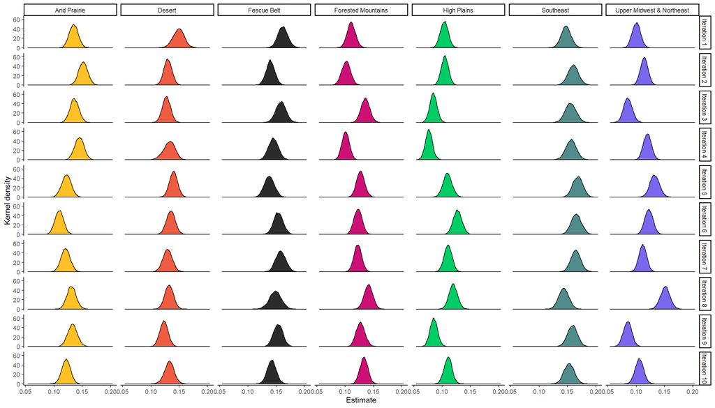

```r
plot_dist_grid(df = h2_sample %>%
                 left_join(n_samples) %>%
                 filter(n_samples >= complete_samples),
               var = mpe2c2)
```

### HPD interval

```r
pivot_hpd("mpe2c2")
```

| Dataset | Iteration 1 | Iteration 2 | Iteration 3 | Iteration 4 | Iteration 5 | Iteration 6 | Iteration 7 | Iteration 8 | Iteration 9 | Iteration 10 |
| --- | --- | --- | --- | --- | --- | --- | --- | --- | --- | --- |
| 3v1 | 0.129, 0.168 (0.039) | 0.116, 0.143 (0.028) | 0.113, 0.141 (0.028) | 0.112, 0.151 (0.039) | 0.126, 0.154 (0.028) | 0.12, 0.151 (0.031) | 0.113, 0.146 (0.033) | 0.117, 0.147 (0.03) | 0.108, 0.137 (0.029) | 0.116, 0.15 (0.034) |
| 3v2 | 0.13, 0.164 (0.034) | 0.142, 0.179 (0.037) | 0.137, 0.174 (0.037) | 0.138, 0.175 (0.037) | 0.152, 0.186 (0.034) | 0.148, 0.184 (0.036) | 0.147, 0.181 (0.034) | 0.126, 0.161 (0.035) | 0.142, 0.176 (0.034) | 0.136, 0.171 (0.035) |
| 3v3alt | 0.09, 0.118 (0.027) | 0.092, 0.118 (0.025) | 0.072, 0.097 (0.025) | 0.064, 0.089 (0.025) | 0.094, 0.125 (0.031) | 0.112, 0.142 (0.03) | 0.097, 0.124 (0.027) | 0.105, 0.134 (0.029) | 0.072, 0.098 (0.026) | 0.097, 0.124 (0.027) |
| 3v5 | 0.12, 0.15 (0.03) | 0.136, 0.168 (0.031) | 0.12, 0.151 (0.031) | 0.128, 0.16 (0.032) | 0.106, 0.138 (0.032) | 0.094, 0.124 (0.03) | 0.105, 0.136 (0.031) | 0.115, 0.146 (0.032) | 0.117, 0.149 (0.033) | 0.107, 0.137 (0.03) |
| 3v7 | 0.096, 0.125 (0.029) | 0.086, 0.117 (0.03) | 0.12, 0.15 (0.03) | 0.089, 0.114 (0.025) | 0.113, 0.141 (0.028) | 0.108, 0.136 (0.028) | 0.109, 0.136 (0.027) | 0.126, 0.156 (0.03) | 0.113, 0.143 (0.03) | 0.12, 0.146 (0.027) |
| 3v8 | 0.145, 0.18 (0.035) | 0.124, 0.155 (0.031) | 0.141, 0.175 (0.035) | 0.128, 0.162 (0.033) | 0.121, 0.155 (0.034) | 0.137, 0.17 (0.034) | 0.141, 0.175 (0.035) | 0.127, 0.168 (0.041) | 0.137, 0.169 (0.032) | 0.126, 0.157 (0.031) |
| 3v9 | 0.086, 0.114 (0.028) | 0.101, 0.127 (0.026) | 0.07, 0.1 (0.03) | 0.107, 0.134 (0.027) | 0.116, 0.15 (0.033) | 0.108, 0.137 (0.029) | 0.098, 0.124 (0.027) | 0.134, 0.167 (0.033) | 0.07, 0.099 (0.029) | 0.091, 0.12 (0.029) |

# Genetic correlations

## High Plains direct & comparison region direct

### All comparisons, all iterations

```r
gibbs_corr %>%
  filter(stringr::str_detect(val1, "3_dir")) %>%
  filter(stringr::str_detect(val2, "dir") & !stringr::str_detect(val2, "3_")) %>%
  mutate(num = as.numeric(stringr::str_extract(val2, "[1-9]"))) %>%
  left_join(region_key %>%
              select(num, desc)) %>%
  mutate(desc = if_else(dataset == "3v3alt", "High Plains (control)", desc)) %>%
  left_join(n_samples) %>%
  filter(n_samples >= complete_samples) %>%
  select(key = desc,
         Iteration = iter,
         Correlation = corr) %>%
  arrange(key, Iteration) %>%
  DT::datatable()
```

|  | key | Iteration | Correlation |
| --- | --- | --- | --- |
| 1 | Arid Prairie | 1 | 0.758 |
| 2 | Arid Prairie | 2 | 0.933 |
| 3 | Arid Prairie | 3 | 0.787 |
| 4 | Arid Prairie | 4 | 0.902 |
| 5 | Arid Prairie | 5 | 0.687 |
| 6 | Arid Prairie | 6 | 0.825 |
| 7 | Arid Prairie | 7 | 0.912 |
| 8 | Arid Prairie | 8 | 0.8 |
| 9 | Arid Prairie | 9 | 0.893 |
| 10 | Arid Prairie | 10 | 0.911 |

[output cut: 60 more lines]

### Summarized by comparison across iterations

- The mean here for most regions is lower than the previous estimate
- Somewhat disconcerting that the High Plains control vs. High Plains “anchor” isn’t the highest estimate (or at least, that it’s as low as it is)

```r
gibbs_corr %>%
  filter(stringr::str_detect(val1, "3_dir")) %>%
  filter(stringr::str_detect(val2, "dir") & !stringr::str_detect(val2, "3_")) %>%
  mutate(num = as.numeric(stringr::str_extract(val2, "[1-9]"))) %>%
  left_join(region_key %>%
              select(num, desc)) %>%
  mutate(desc = if_else(dataset == "3v3alt", "High Plains (control)", desc)) %>%
  left_join(n_samples) %>%
  filter(n_samples >= complete_samples) %>%
  select(Comparison = desc,
         Iteration = iter,
         Correlation = corr) %>%
  group_by(Comparison) %>%
  summarise(`Min.` = min(Correlation),
            Mean = mean(Correlation),
            `Max.` = max(Correlation),
            SD = sd(Correlation),
            n = n())
```

| Comparison | Min. | Mean | Max. | SD | n |
| --- | --- | --- | --- | --- | --- |
| Arid Prairie | 0.687 | 0.8408 | 0.933 | 0.08184511 | 10 |
| Desert | 0.721 | 0.8315 | 0.921 | 0.06020197 | 10 |
| Fescue Belt | 0.546 | 0.7954 | 0.890 | 0.11004565 | 10 |
| Forested Mountains | 0.778 | 0.8679 | 0.932 | 0.05361685 | 10 |
| High Plains (control) | 0.741 | 0.8325 | 0.936 | 0.06514812 | 10 |
| Southeast | 0.746 | 0.8190 | 0.904 | 0.05672742 | 10 |
| Upper Midwest & Northeast | 0.727 | 0.8075 | 0.972 | 0.08152334 | 10 |

### Distribution

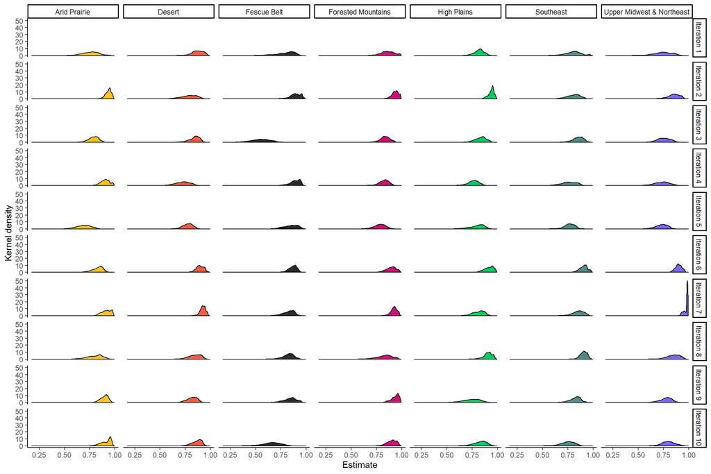

```r
plot_dist_grid(df = rg_sample %>%
                 left_join(n_samples) %>%
                 filter(n_samples >= complete_samples),
               var = rgdir1dir2)
```

### HPD interval

```r
pivot_hpd("rgdir1dir2")
```

| Dataset | Iteration 1 | Iteration 2 | Iteration 3 | Iteration 4 | Iteration 5 | Iteration 6 | Iteration 7 | Iteration 8 | Iteration 9 | Iteration 10 |
| --- | --- | --- | --- | --- | --- | --- | --- | --- | --- | --- |
| 3v1 | 0.77, 0.967 (0.197) | 0.634, 0.914 (0.281) | 0.727, 0.925 (0.198) | 0.581, 0.849 (0.267) | 0.673, 0.866 (0.193) | 0.813, 0.965 (0.152) | 0.87, 0.975 (0.104) | 0.736, 0.946 (0.21) | 0.714, 0.899 (0.185) | 0.768, 0.937 (0.169) |
| 3v2 | 0.66, 0.97 (0.309) | 0.68, 0.92 (0.24) | 0.738, 0.94 (0.202) | 0.607, 0.884 (0.277) | 0.642, 0.871 (0.23) | 0.829, 0.98 (0.151) | 0.725, 0.952 (0.227) | 0.837, 0.963 (0.125) | 0.712, 0.929 (0.218) | 0.626, 0.87 (0.244) |
| 3v3alt | 0.723, 0.91 (0.187) | 0.873, 0.984 (0.111) | 0.729, 0.93 (0.201) | 0.64, 0.869 (0.229) | 0.625, 0.914 (0.289) | 0.82, 0.991 (0.171) | 0.703, 0.919 (0.216) | 0.817, 0.98 (0.162) | 0.555, 0.888 (0.333) | 0.706, 0.936 (0.231) |
| 3v5 | 0.601, 0.911 (0.31) | 0.879, 0.983 (0.104) | 0.699, 0.884 (0.185) | 0.824, 0.988 (0.164) | 0.55, 0.823 (0.273) | 0.708, 0.915 (0.207) | 0.832, 0.981 (0.149) | 0.649, 0.924 (0.275) | 0.822, 0.964 (0.142) | 0.818, 0.979 (0.161) |
| 3v7 | 0.749, 0.988 (0.238) | 0.869, 0.993 (0.124) | 0.739, 0.927 (0.188) | 0.712, 0.916 (0.204) | 0.649, 0.892 (0.243) | 0.799, 0.977 (0.178) | 0.858, 0.977 (0.119) | 0.683, 0.961 (0.278) | 0.852, 0.989 (0.137) | 0.815, 0.977 (0.162) |
| 3v8 | 0.611, 0.926 (0.316) | 0.789, 0.987 (0.198) | 0.366, 0.724 (0.358) | 0.781, 0.965 (0.184) | 0.703, 0.957 (0.253) | 0.787, 0.94 (0.153) | 0.695, 0.917 (0.222) | 0.714, 0.927 (0.214) | 0.715, 0.953 (0.238) | 0.48, 0.82 (0.34) |
| 3v9 | 0.575, 0.904 (0.328) | 0.733, 0.95 (0.218) | 0.638, 0.866 (0.229) | 0.577, 0.874 (0.297) | 0.597, 0.831 (0.234) | 0.837, 0.964 (0.127) | 0.926, 0.993 (0.067) | 0.729, 0.954 (0.225) | 0.641, 0.881 (0.24) | 0.678, 0.918 (0.24) |

## High Plains maternal & comparison region maternal

### All comparisons, all iterations

```r
gibbs_corr %>%
  filter(stringr::str_detect(val1, "3_mat")) %>%
  filter(stringr::str_detect(val2, "mat") & !stringr::str_detect(val2, "3_")) %>%
  mutate(num = as.numeric(stringr::str_extract(val2, "[1-9]"))) %>%
  left_join(region_key %>%
              select(num, desc)) %>%
  mutate(desc = if_else(dataset == "3v3alt", "High Plains (control)", desc)) %>%
  left_join(n_samples) %>%
  filter(n_samples >= complete_samples) %>%
  select(Comparison = desc,
         Iteration = iter,
         Correlation = corr) %>%
  arrange(Comparison, Iteration) %>%
  DT::datatable()
```

|  | Comparison | Iteration | Correlation |
| --- | --- | --- | --- |
| 1 | Arid Prairie | 1 | 0.781 |
| 2 | Arid Prairie | 2 | 0.815 |
| 3 | Arid Prairie | 3 | 0.65 |
| 4 | Arid Prairie | 4 | 0.737 |
| 5 | Arid Prairie | 5 | 0.553 |
| 6 | Arid Prairie | 6 | 0.708 |
| 7 | Arid Prairie | 7 | 0.721 |
| 8 | Arid Prairie | 8 | 0.663 |
| 9 | Arid Prairie | 9 | 0.634 |
| 10 | Arid Prairie | 10 | 0.643 |

[output cut: 60 more lines]

### Summarized by comparison across iterations

- Again, much lower than previous estimates for most regions.
- Below 0.8 even in the High Plains control

```r
gibbs_corr %>%
  filter(stringr::str_detect(val1, "3_mat")) %>%
  filter(stringr::str_detect(val2, "mat") & !stringr::str_detect(val2, "3_")) %>%
  mutate(num = as.numeric(stringr::str_extract(val2, "[1-9]"))) %>%
  left_join(region_key %>%
              select(num, desc)) %>%
  mutate(desc = if_else(dataset == "3v3alt", "High Plains (control)", desc)) %>%
  left_join(n_samples) %>%
  filter(n_samples >= complete_samples) %>%
  select(Comparison = desc,
         Iteration = iter,
         Correlation = corr) %>%
  group_by(Comparison) %>%
  summarise(`Min.` = min(Correlation),
            Mean = mean(Correlation),
            `Max.` = max(Correlation),
            SD = sd(Correlation),
            n = n_distinct(Iteration))
```

| Comparison | Min. | Mean | Max. | SD | n |
| --- | --- | --- | --- | --- | --- |
| Arid Prairie | 0.553 | 0.6905 | 0.815 | 0.07734519 | 10 |
| Desert | 0.548 | 0.7410 | 0.881 | 0.11921409 | 10 |
| Fescue Belt | 0.507 | 0.6967 | 0.881 | 0.10254327 | 10 |
| Forested Mountains | 0.553 | 0.7657 | 0.884 | 0.10613728 | 10 |
| High Plains (control) | 0.646 | 0.7642 | 0.854 | 0.06616444 | 10 |
| Southeast | 0.470 | 0.6649 | 0.814 | 0.09437449 | 10 |
| Upper Midwest & Northeast | 0.503 | 0.7439 | 0.911 | 0.13402773 | 10 |

### Distribution

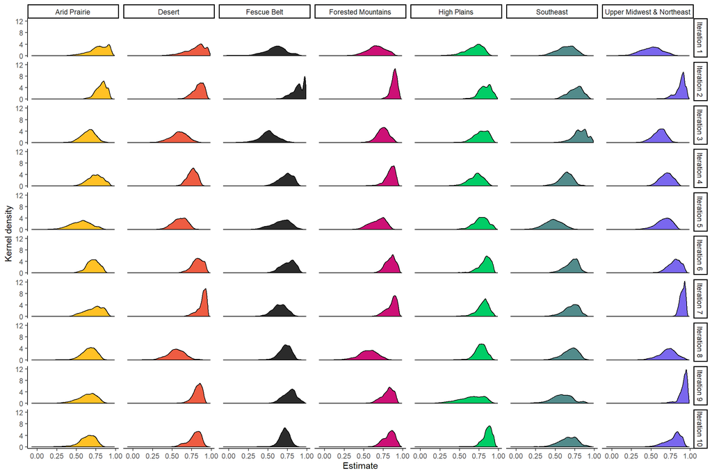

```r
plot_dist_grid(df = rg_sample %>%
                 left_join(n_samples) %>%
                 filter(n_samples >= complete_samples),
               var = rgmat1mat2)
```

### HPD interval

```r
pivot_hpd("rgmat1mat2")
```

| Dataset | Iteration 1 | Iteration 2 | Iteration 3 | Iteration 4 | Iteration 5 | Iteration 6 | Iteration 7 | Iteration 8 | Iteration 9 | Iteration 10 |
| --- | --- | --- | --- | --- | --- | --- | --- | --- | --- | --- |
| 3v1 | 0.562, 0.976 (0.414) | 0.693, 0.949 (0.256) | 0.365, 0.79 (0.425) | 0.629, 0.868 (0.239) | 0.417, 0.761 (0.344) | 0.68, 0.951 (0.271) | 0.751, 0.959 (0.208) | 0.322, 0.748 (0.426) | 0.701, 0.929 (0.228) | 0.604, 0.912 (0.308) |
| 3v2 | 0.413, 0.833 (0.42) | 0.573, 0.916 (0.343) | 0.649, 0.981 (0.332) | 0.427, 0.797 (0.369) | 0.242, 0.691 (0.449) | 0.515, 0.863 (0.348) | 0.512, 0.89 (0.378) | 0.488, 0.855 (0.366) | 0.351, 0.889 (0.538) | 0.446, 0.895 (0.449) |
| 3v3alt | 0.479, 0.881 (0.402) | 0.682, 0.97 (0.288) | 0.606, 0.929 (0.324) | 0.513, 0.891 (0.379) | 0.607, 0.953 (0.346) | 0.663, 0.944 (0.281) | 0.637, 0.946 (0.309) | 0.636, 0.905 (0.27) | 0.334, 0.904 (0.57) | 0.736, 0.956 (0.22) |
| 3v5 | 0.551, 0.954 (0.403) | 0.69, 0.935 (0.246) | 0.47, 0.817 (0.348) | 0.566, 0.925 (0.359) | 0.303, 0.813 (0.51) | 0.55, 0.865 (0.314) | 0.505, 0.905 (0.4) | 0.499, 0.833 (0.334) | 0.39, 0.842 (0.452) | 0.449, 0.821 (0.372) |
| 3v7 | 0.449, 0.879 (0.43) | 0.807, 0.965 (0.158) | 0.6, 0.894 (0.293) | 0.693, 0.943 (0.25) | 0.478, 0.843 (0.365) | 0.719, 0.955 (0.236) | 0.711, 0.955 (0.243) | 0.32, 0.776 (0.456) | 0.651, 0.93 (0.279) | 0.682, 0.953 (0.271) |
| 3v8 | 0.34, 0.875 (0.535) | 0.727, 0.986 (0.26) | 0.263, 0.724 (0.461) | 0.552, 0.887 (0.335) | 0.411, 0.871 (0.46) | 0.585, 0.913 (0.328) | 0.472, 0.824 (0.351) | 0.572, 0.855 (0.283) | 0.597, 0.929 (0.333) | 0.589, 0.839 (0.25) |
| 3v9 | 0.252, 0.749 (0.497) | 0.733, 0.975 (0.242) | 0.433, 0.758 (0.325) | 0.54, 0.85 (0.31) | 0.463, 0.839 (0.376) | 0.644, 0.942 (0.298) | 0.835, 0.958 (0.123) | 0.508, 0.936 (0.428) | 0.796, 0.982 (0.186) | 0.586, 0.932 (0.346) |

## High Plains direct & comparison region maternal

### All comparisons, all iterations

```r
gibbs_corr %>%
  filter(stringr::str_detect(val1, "3_dir")) %>%
  filter(stringr::str_detect(val2, "mat") & !stringr::str_detect(val2, "3_")) %>%
  mutate(num = as.numeric(stringr::str_extract(val2, "[1-9]"))) %>%
  left_join(region_key %>%
              select(num, desc)) %>%
  mutate(desc = if_else(dataset == "3v3alt", "High Plains (control)", desc)) %>%
  left_join(n_samples) %>%
  filter(n_samples >= complete_samples) %>%
  select(Comparison = desc,
         Iteration = iter,
         Correlation = corr) %>%
  arrange(Comparison, Iteration) %>%
  DT::datatable()
```

|  | Comparison | Iteration | Correlation |
| --- | --- | --- | --- |
| 1 | Arid Prairie | 1 | -0.184 |
| 2 | Arid Prairie | 2 | -0.387 |
| 3 | Arid Prairie | 3 | -0.0988 |
| 4 | Arid Prairie | 4 | -0.266 |
| 5 | Arid Prairie | 5 | -0.113 |
| 6 | Arid Prairie | 6 | -0.244 |
| 7 | Arid Prairie | 7 | -0.286 |
| 8 | Arid Prairie | 8 | -0.182 |
| 9 | Arid Prairie | 9 | -0.161 |
| 10 | Arid Prairie | 10 | -0.139 |

[output cut: 60 more lines]

### Summarized by comparison across iterations

```r
gibbs_corr %>%
  filter(str_detect(val1, "3_dir")) %>%
  filter(str_detect(val2, "mat") & !str_detect(val2, "3_")) %>%
  mutate(num = as.numeric(str_extract(val2, "[1-9]"))) %>%
  left_join(region_key %>%
              select(num, desc)) %>%
  mutate(desc = if_else(dataset == "3v3alt", "High Plains (control)", desc)) %>%
  left_join(n_samples) %>%
  filter(n_samples >= complete_samples) %>%
  select(Comparison = desc,
         Iteration = iter,
         Correlation = corr) %>%
  group_by(Comparison) %>%
  summarise(`Min.` = min(Correlation),
            Mean = mean(Correlation),
            `Max.` = max(Correlation),
            SD = sd(Correlation),
            n = n_distinct(Iteration))
```

| Comparison | Min. | Mean | Max. | SD | n |
| --- | --- | --- | --- | --- | --- |
| Arid Prairie | -0.387 | -0.2060800 | -0.098800 | 0.08939288 | 10 |
| Desert | -0.377 | -0.2578000 | -0.118000 | 0.09525848 | 10 |
| Fescue Belt | -0.443 | -0.2169624 | -0.000224 | 0.12721460 | 10 |
| Forested Mountains | -0.329 | -0.1502800 | -0.015500 | 0.11310664 | 10 |
| High Plains (control) | -0.334 | -0.1896000 | -0.103000 | 0.07238201 | 10 |
| Southeast | -0.389 | -0.2507100 | -0.054100 | 0.11959318 | 10 |
| Upper Midwest & Northeast | -0.553 | -0.2272500 | 0.010600 | 0.15960672 | 10 |

### Distribution

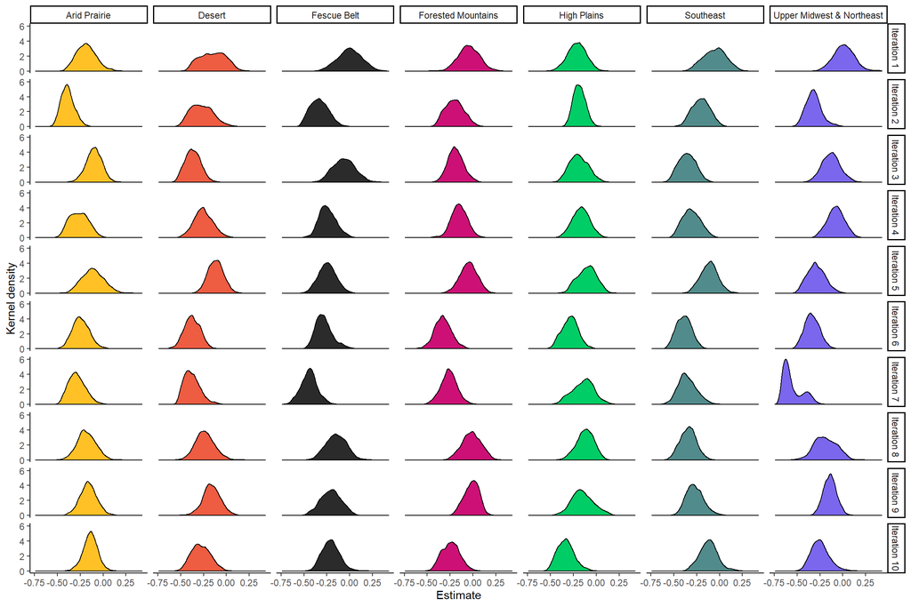

```r
plot_dist_grid(df = rg_sample %>%
                 left_join(n_samples) %>%
                 filter(n_samples >= complete_samples),
               var = rgdir1mat2)
```

### HPD interval

```r
pivot_hpd("rgdir1mat2")
```

| Dataset | Iteration 1 | Iteration 2 | Iteration 3 | Iteration 4 | Iteration 5 | Iteration 6 | Iteration 7 | Iteration 8 | Iteration 9 | Iteration 10 |
| --- | --- | --- | --- | --- | --- | --- | --- | --- | --- | --- |
| 3v1 | -0.397, 0.09 (0.488) | -0.485, -0.029 (0.456) | -0.529, -0.205 (0.324) | -0.451, -0.038 (0.413) | -0.289, 0.045 (0.334) | -0.546, -0.209 (0.338) | -0.532, -0.202 (0.329) | -0.442, -0.029 (0.412) | -0.361, 0.036 (0.397) | -0.48, -0.085 (0.396) |
| 3v2 | -0.29, 0.18 (0.47) | -0.394, -0.016 (0.378) | -0.533, -0.177 (0.355) | -0.485, -0.114 (0.371) | -0.305, 0.074 (0.378) | -0.547, -0.23 (0.317) | -0.539, -0.139 (0.4) | -0.518, -0.176 (0.342) | -0.451, -0.077 (0.374) | -0.331, 0.064 (0.395) |
| 3v3alt | -0.416, -0.018 (0.398) | -0.308, -0.05 (0.258) | -0.387, 0.007 (0.394) | -0.356, 0.019 (0.375) | -0.301, 0.089 (0.39) | -0.468, -0.12 (0.348) | -0.38, 0.083 (0.463) | -0.31, 0.056 (0.366) | -0.378, 0.099 (0.477) | -0.511, -0.154 (0.357) |
| 3v5 | -0.389, 0.025 (0.414) | -0.522, -0.237 (0.285) | -0.273, 0.066 (0.339) | -0.449, -0.069 (0.38) | -0.344, 0.118 (0.462) | -0.414, -0.051 (0.363) | -0.458, -0.106 (0.352) | -0.376, 0.022 (0.398) | -0.35, 0.019 (0.369) | -0.308, 0.015 (0.323) |
| 3v7 | -0.282, 0.167 (0.449) | -0.401, -0.016 (0.385) | -0.357, -0.015 (0.342) | -0.325, 0.027 (0.352) | -0.234, 0.141 (0.374) | -0.52, -0.14 (0.38) | -0.445, -0.083 (0.362) | -0.212, 0.185 (0.398) | -0.175, 0.133 (0.308) | -0.429, -0.062 (0.367) |
| 3v8 | -0.249, 0.26 (0.509) | -0.524, -0.149 (0.376) | -0.287, 0.173 (0.46) | -0.408, -0.039 (0.369) | -0.433, -0.054 (0.38) | -0.443, -0.074 (0.369) | -0.625, -0.265 (0.36) | -0.369, 0.05 (0.42) | -0.422, 0.013 (0.435) | -0.388, -0.02 (0.368) |
| 3v9 | -0.223, 0.221 (0.444) | -0.497, -0.148 (0.349) | -0.316, 0.083 (0.399) | -0.265, 0.104 (0.369) | -0.48, -0.102 (0.379) | -0.497, -0.177 (0.32) | -0.694, -0.334 (0.361) | -0.4, 0.053 (0.453) | -0.279, 0.005 (0.284) | -0.43, -0.044 (0.386) |

## Within-region direct & maternal

### All comparisons, all iterations

```r
gibbs_corr %>%
  mutate(r1 = stringr::str_extract(val1, "[[:alnum:]]+(?=_)"),
         r2 = stringr::str_extract(val2, "[[:alnum:]]+(?=_)")) %>%
  filter(r1 == r2) %>%
  filter(stringr::str_detect(val1, "dir")) %>%
  filter(stringr::str_detect(val2, "mat")) %>%
  mutate(num = as.numeric(r1)) %>%
  left_join(region_key %>%
              select(num, desc)) %>%
  mutate(desc = case_when(is.na(desc) & stringr::str_detect(dataset, "3alt") ~ "High Plains (control)",
                          desc == "High Plains" ~ "High Plains (anchor)",
                          TRUE ~ desc)) %>%
  left_join(n_samples) %>%
  filter(n_samples >= complete_samples) %>%
  select(Comparison = desc,
         Iteration = iter,
         Correlation = corr) %>%
  arrange(Comparison, Iteration) %>%
  DT::datatable()
```

|  | Comparison | Iteration | Correlation |
| --- | --- | --- | --- |
| 1 | Arid Prairie | 1 | -0.478 |
| 2 | Arid Prairie | 2 | -0.402 |
| 3 | Arid Prairie | 3 | -0.411 |
| 4 | Arid Prairie | 4 | -0.33 |
| 5 | Arid Prairie | 5 | -0.26 |
| 6 | Arid Prairie | 6 | -0.455 |
| 7 | Arid Prairie | 7 | -0.347 |
| 8 | Arid Prairie | 8 | -0.402 |
| 9 | Arid Prairie | 9 | -0.357 |
| 10 | Arid Prairie | 10 | -0.285 |

[output cut: 130 more lines]

### Summarized by comparison across iterations

```r
gibbs_corr %>%
  mutate(r1 = stringr::str_extract(val1, "[[:alnum:]]+(?=_)"),
         r2 = stringr::str_extract(val2, "[[:alnum:]]+(?=_)")) %>%
  filter(r1 == r2) %>%
  filter(stringr::str_detect(val1, "dir")) %>%
  filter(stringr::str_detect(val2, "mat")) %>%
  mutate(num = as.numeric(r1)) %>%
  left_join(region_key %>%
              select(num, desc)) %>%
  mutate(desc = case_when(is.na(desc) & stringr::str_detect(dataset, "3alt") ~ "High Plains (control)",
                          desc == "High Plains" ~ "High Plains (anchor)",
                          TRUE ~ desc)) %>%
  left_join(n_samples) %>%
  filter(n_samples >= complete_samples) %>%
  select(Comparison = desc,
         Iteration = iter,
         Correlation = corr) %>%
  group_by(Comparison) %>%
  summarise(`Min.` = min(Correlation),
            Mean = mean(Correlation),
            `Max.` = max(Correlation),
            SD = sd(Correlation),
            n = n())
```

| Comparison | Min. | Mean | Max. | SD | n |
| --- | --- | --- | --- | --- | --- |
| Arid Prairie | -0.478 | -0.3727000 | -0.260 | 0.07005403 | 10 |
| Desert | -0.480 | -0.3673000 | -0.236 | 0.08468642 | 10 |
| Fescue Belt | -0.525 | -0.3967000 | -0.279 | 0.08368200 | 10 |
| Forested Mountains | -0.425 | -0.2781000 | -0.189 | 0.06595866 | 10 |
| High Plains (anchor) | -0.427 | -0.2974429 | -0.166 | 0.08155280 | 70 |
| High Plains (control) | -0.377 | -0.2630000 | -0.100 | 0.08115965 | 10 |
| Southeast | -0.482 | -0.3931000 | -0.294 | 0.06489898 | 10 |
| Upper Midwest & Northeast | -0.474 | -0.3800000 | -0.308 | 0.06278535 | 10 |

### Distribution

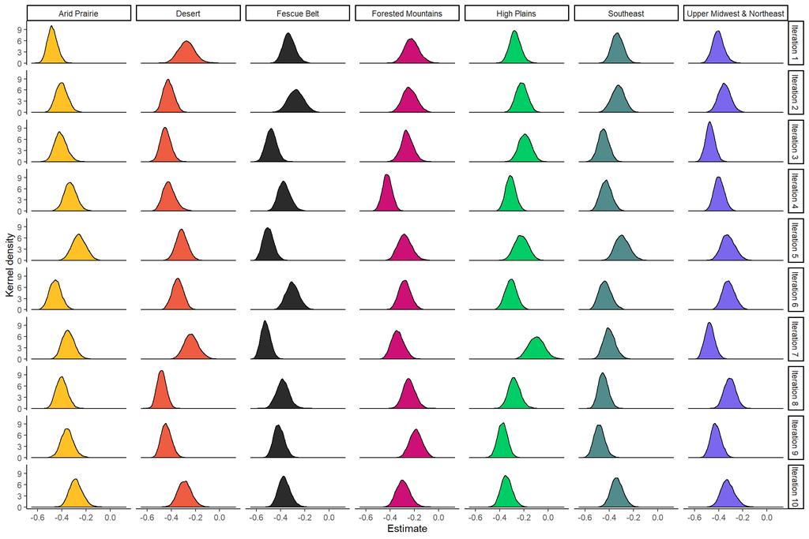

```r
plot_dist_grid(df = rg_sample %>%
                 left_join(n_samples) %>%
                 filter(n_samples >= complete_samples),
               var = rgdir2mat2)
```

### HPD interval

```r
pivot_hpd("rgdir2mat2")
```

| Dataset | Iteration 1 | Iteration 2 | Iteration 3 | Iteration 4 | Iteration 5 | Iteration 6 | Iteration 7 | Iteration 8 | Iteration 9 | Iteration 10 |
| --- | --- | --- | --- | --- | --- | --- | --- | --- | --- | --- |
| 3v1 | -0.413, -0.144 (0.269) | -0.505, -0.333 (0.171) | -0.533, -0.36 (0.173) | -0.515, -0.308 (0.207) | -0.412, -0.22 (0.192) | -0.437, -0.258 (0.179) | -0.343, -0.109 (0.234) | -0.551, -0.406 (0.145) | -0.519, -0.352 (0.167) | -0.399, -0.181 (0.218) |
| 3v2 | -0.426, -0.239 (0.187) | -0.436, -0.226 (0.21) | -0.535, -0.36 (0.175) | -0.516, -0.331 (0.185) | -0.404, -0.179 (0.225) | -0.527, -0.329 (0.198) | -0.49, -0.3 (0.19) | -0.522, -0.363 (0.16) | -0.568, -0.393 (0.175) | -0.432, -0.236 (0.196) |
| 3v3alt | -0.367, -0.181 (0.186) | -0.307, -0.123 (0.184) | -0.29, -0.09 (0.2) | -0.389, -0.227 (0.162) | -0.333, -0.112 (0.221) | -0.401, -0.213 (0.188) | -0.228, 0.02 (0.249) | -0.373, -0.18 (0.193) | -0.458, -0.296 (0.163) | -0.434, -0.25 (0.185) |
| 3v5 | -0.556, -0.394 (0.163) | -0.495, -0.305 (0.19) | -0.507, -0.305 (0.202) | -0.431, -0.226 (0.205) | -0.367, -0.147 (0.22) | -0.547, -0.358 (0.189) | -0.439, -0.242 (0.198) | -0.485, -0.306 (0.179) | -0.458, -0.246 (0.212) | -0.385, -0.175 (0.209) |
| 3v7 | -0.342, -0.102 (0.239) | -0.353, -0.124 (0.228) | -0.361, -0.158 (0.202) | -0.504, -0.35 (0.154) | -0.385, -0.164 (0.221) | -0.375, -0.183 (0.193) | -0.437, -0.236 (0.201) | -0.339, -0.142 (0.197) | -0.287, -0.085 (0.203) | -0.397, -0.184 (0.214) |
| 3v8 | -0.425, -0.228 (0.197) | -0.399, -0.149 (0.25) | -0.562, -0.389 (0.173) | -0.47, -0.273 (0.198) | -0.589, -0.419 (0.17) | -0.405, -0.192 (0.214) | -0.598, -0.447 (0.151) | -0.485, -0.277 (0.207) | -0.498, -0.326 (0.172) | -0.468, -0.274 (0.194) |
| 3v9 | -0.494, -0.309 (0.185) | -0.452, -0.251 (0.201) | -0.543, -0.394 (0.149) | -0.478, -0.313 (0.165) | -0.43, -0.208 (0.222) | -0.41, -0.215 (0.196) | -0.552, -0.394 (0.158) | -0.395, -0.214 (0.181) | -0.507, -0.34 (0.167) | -0.43, -0.21 (0.22) |